# A/B Testing

snelson

August 6, 2015

This RST will attempt to cover a lot of ground in a short amount of time. Here are the topics:

- A/B testing (design of experiments)
- Multiple hypothesis testing (controlling for data-snooping bias)

## Multi-armed bandits (adaptive testing)

## 1) AB Testing

### Problem

- We have formed a hypothesis and we want to test whether it’s true using a controlled experiment

### Solution strategy

- We run a randomized controlled experiment, which consists of applying a control to the control group, and a treatment to the treatment group, where subjects are randomly assigned to either the treatment or control group, and the group sizes are large enough to ensure statistical significance.
- We compare the outcomes from both groups to evaluate the impact (lift) of the treatment.

### Method

1. Design experiment:
- Identify factors and levels for the treatment
- Sample size calculations
2. Randomize assignment of patients
3. Run experiment
4. Evaluate results

### Example: Ads

Curate an audience by retrieving a list of Twitter user_ids:

```
#bash code to retrieve follower_ids and concatenate into a list
#twurl /1.1/followers/ids.json?screen_name=s1nelson > s1nelson_followers.txt
#twurl /1.1/followers/ids.json?screen_name=jrmontag > jrmontag_followers.txt
#twurl /1.1/followers/ids.json?screen_name=kolb > kolb_followers.txt
#twurl /1.1/followers/ids.json?screen_name=drkippy > drskippy_followers.txt
#twurl /1.1/followers/ids.json?screen_name=notFromShrek > fiona_followers.txt
#find . -name "*followers*" | xargs -I {} cat {} | jq .ids[] | sort | uniq > ta.txt
#wc -l ta.txt
```

Sample size calculations: The following assumes we want to compare **proportions** between **2** groups with independent samples from each.

The probability model assumes that **each observation** is drawn from a binomial distribution.

For each group $j$ we have $x_j$ successes in $n_j$ trials.

A sum of 2 binomial random variables is also binomial, i.e. $X~B(n, p)+Y~B(m,p)=B(m+n, p).

Hence we can collapse observations into a sum for each group.

To be specific, we want to test the means of both groups and see if they are different, i.e. $H_0:p_1=p_2$ versus $H_A:p_1\neq p_2$.

The sampling distribution for the MEAN PARAMETER $p$ has mean $p$ and variance $\sigma=\sqrt{p*(1-p)/n)}$.

```r
#sample size calc
#power.prop.test
#https://stat.ethz.ch/R-manual/R-devel/library/stats/html/power.prop.test.html
# need a baseline estimate. e.g. p=0.03

#test of equal proportions
#prop.test
#https://stat.ethz.ch/R-manual/R-devel/library/stats/html/prop.test.html


#with a baseline rate of 0.03 and we want to detect a improvement of 0.02 --> ## #need 1186*2 => sample size 2372
power.prop.test(p1=0.03, p2=0.05, power = .80, sig.level=.05, alternative="one.sided")
```

```
##
##      Two-sample comparison of proportions power calculation
##
##               n = 1186.004
##              p1 = 0.03
##              p2 = 0.05
##       sig.level = 0.05
##           power = 0.8
##     alternative = one.sided
##
## NOTE: n is number in *each* group
```

```r
#with a baseline rate of 0.03 and we want to detect a improvement of 0.01
#need 4175*2 => sample size 8350
power.prop.test(p1=0.03, p2=0.04, power = .80, sig.level=.05, alternative="one.sided")
```

```
##
##      Two-sample comparison of proportions power calculation
##
##               n = 4175.271
##              p1 = 0.03
##              p2 = 0.04
##       sig.level = 0.05
##           power = 0.8
##     alternative = one.sided
##
## NOTE: n is number in *each* group
```

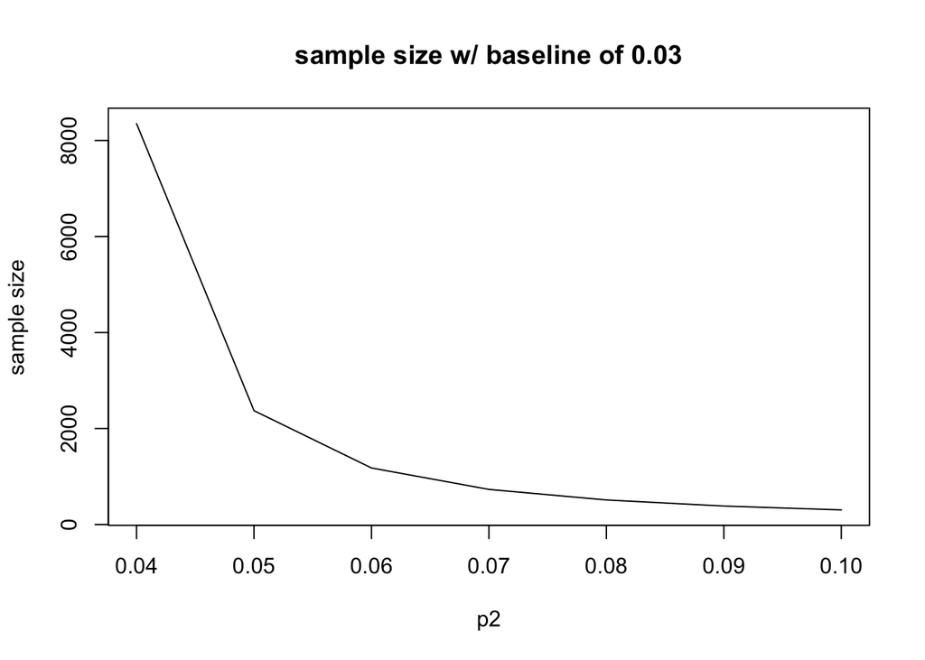

```r
#sensitivity of required sample size to p2, assuming baseline of 0.03
power_calc<-function(p2){
  a<-power.prop.test(p1=0.03, p2=p2, power = .80, sig.level=.05, alternative="one.sided")
  return(a$n*2)
}
c<-seq(0.04, 0.10, 0.01)
res<-sapply(c, power_calc)
plot(x=c, y=res, type="l", xlab="p2", ylab="sample size", main="sample size w/ baseline of 0.03")
```

## Design of Experiments

[Ad 1](https://twitter.com/s1nelson/status/623875993371971584) [Ad 2](https://twitter.com/s1nelson/status/623877238816047105)

- Factors + Levels

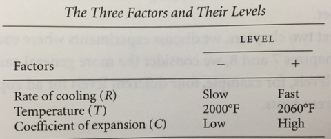

- Design:
  - Varying 1 factor at a time: requires 16 runs

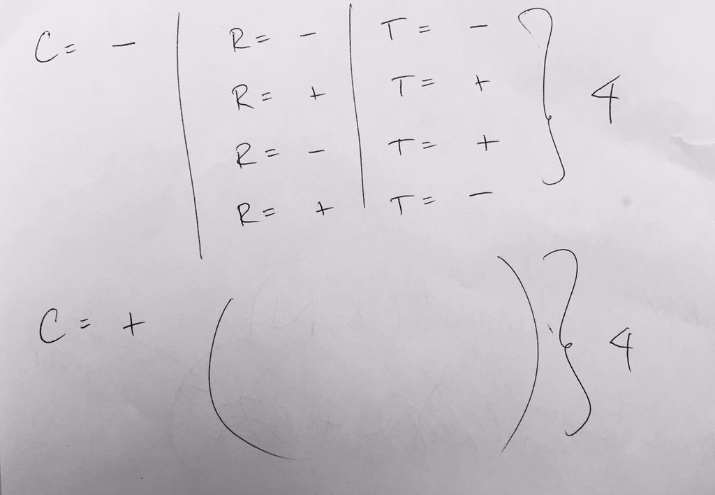

```
- Factorial Design: requires only 8 runs
```

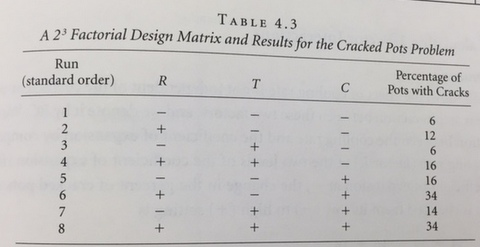

```
- Interactions
```

## Analysis

```r
# analyze results
# load data from sample Twitter Ads campaign
t<-seq(1,15)
imp_img<-c(89,92,57,49,44,152,11,0,0,0,0,0,0,0,0)
eng_img<-c(10,8,0,0,2,5,1,0,0,0,0,0,0,0,0)
imp_no_img<-c(58,217,0,0,0,0,0,0,0,0,0,0,0,0,0)
eng_no_img<-c(2,16,0,0,0,0,0,0,0,0,0, 0,0,0,0)
data<-data.frame(t, imp_img, eng_img, imp_no_img, eng_no_img)

# t-test assumes completely randomized design
prop.test( c(sum(data$eng_img), sum(data$eng_no_img)),
           c(sum(data$imp_img), sum(data$imp_no_img)))
```

```
##
##  2-sample test for equality of proportions with continuity
##  correction
##
## data:  c(sum(data$eng_img), sum(data$eng_no_img)) out of c(sum(data$imp_img), sum(data$imp_no_img))
## X-squared = 0.32701, df = 1, p-value = 0.5674
## alternative hypothesis: two.sided
## 95 percent confidence interval:
##  -0.05089841  0.02525248
## sample estimates:
##     prop 1     prop 2
## 0.05263158 0.06545455
```

```r
#adjusting for the impression bias
#phats
overall_eng_rate_img<-sum(data$eng_img)/sum(data$imp_img)
overall_eng_rate_no_img<-sum(data$eng_no_img)/sum(data$imp_no_img)
#se_phats
se_phat_img<-((overall_eng_rate_img*(1-overall_eng_rate_img))/sum(data$imp_img))^0.5
se_phat_no_img<-((overall_eng_rate_no_img*(1-overall_eng_rate_no_img))/sum(data$imp_no_img))^0.5
#adj phats
adj_phat_img<-overall_eng_rate_img/se_phat_img
adj_phat_no_img<-overall_eng_rate_no_img/se_phat_no_img
```

Ratio of performance metrics. Image improves baseline by 20%: Ratio: 1.193689

### Analysis of Variance

- What if there is variation in the day-of-week?
- This implies a need for [blocking](https://en.wikipedia.org/wiki/Randomized_block_design)
- If 1 day of the week generates all the impressions / engagements, this may be misleading
- Not sure what the “correct” strategy is (since we have impressions which depends on ad quality), but one possibility is to calculate per-day adjusted phats and run ANOVA on this variable, with blocking factor=time period, and treatment=ad:

```r
##anova analysis
a<-data[,(1:3)]
a$img<-1
names(a)<-c("t", "imp", "eng", "img")
b<-data[,c(1,4,5)]
b$img<-0
names(b)<-c("t", "imp", "eng", "img")
data2<-rbind(a,b )
data2$img<-as.factor(data2$img)
data2$t<-as.factor(data2$t)
data2$phat<-data2$eng/data2$imp
data2$adj_phat<-data2$phat / (( data2$phat* (1-data2$phat) /data2$imp )**0.5)
data2
```

```
##     t imp eng img       phat adj_phat
## 1   1  89  10   1 0.11235955 3.356460
## 2   2  92   8   1 0.08695652 2.960051
## 3   3  57   0   1 0.00000000      NaN
## 4   4  49   0   1 0.00000000      NaN
## 5   5  44   2   1 0.04545455 1.447494
## 6   6 152   5   1 0.03289474 2.273778
## 7   7  11   1   1 0.09090909 1.048809
## 8   8   0   0   1        NaN      NaN
## 9   9   0   0   1        NaN      NaN
## 10 10   0   0   1        NaN      NaN
## 11 11   0   0   1        NaN      NaN
## 12 12   0   0   1        NaN      NaN
## 13 13   0   0   1        NaN      NaN
## 14 14   0   0   1        NaN      NaN
```

[output cut: 16 more lines]

```r
fit<-aov(adj_phat~t+img, data=data2)
summary(fit)
```

```
##             Df Sum Sq Mean Sq F value Pr(>F)
## t            4  5.429   1.357   0.560  0.748
## img          1  0.130   0.130   0.054  0.855
## Residuals    1  2.423   2.423
## 23 observations deleted due to missingness
```

### Diff-in-Diff

- If we can take the pre-campaign levels of engagement for each group, we can calculate engagement uplift from each ad, relative to the pre-test levels for each group
- This controls for any systematic bias in the responses of each group

## 2) Multiple Hypothesis Testing

### Problem

- if we run many tests, some will pass by chance alone
- hypothesis testing and p-values are designed for a single test

P(at least 1 significant result)=1-P(no sig results) =1-(1-.05)**20 ~=0.64

### Methods

- *Bonferroni correction* (statistics): Penalize the p-value required for a result to be deemed signficiant
- *False discovery rate* (statistics): control the expected proportion of rejected null hypotheses that were incorrect rejections
- *Optimal discovery procedure* (genetics): maximizes the number of expected true positives for each fixed number of expected false positives
- *Reality Check / Superior Predictive Ability* (econometrics): correct for data-snooping bias – does a given strategy really outperform the benchmark?

### Example

See this [set of lecture notes]: (http://www.stat.berkeley.edu/~mgoldman/Section0402.pdf):

```r
#simulate first 900 w/ standard normal, last 100 w/ mean 3
x <- c(rnorm(900), rnorm(100, mean = 3))
#calc p-values
p <- pnorm(x, lower.tail = F)
```

**No corrections**:

```r
test <- p > 0.05
summary(test[1:900])
```

```
##    Mode   FALSE    TRUE    NA's
## logical      33     867       0
```

```r
summary(test[901:1000])
```

```
##    Mode   FALSE    TRUE    NA's
## logical      98       2       0
```

False positive rate: 0.0366667

False negative rate: 0.02

**Bonferroni correction**:

```r
bonftest <- p > 0.00005
summary(bonftest[1:900])
```

```
##    Mode    TRUE    NA's
## logical     900       0
```

```r
summary(bonftest[901:1000])
```

```
##    Mode   FALSE    TRUE    NA's
## logical      27      73       0
```

False negative rate: 0.73

We’ve reduced false positives but increased our false negatives

**False Discovery Rate**: Sort the pvalues; See if the k-th p-value is greater than k*.05 / 1000:

```r
psort <- sort(p)
fdrtest <- NULL
for (i in 1:1000)
fdrtest <- c(fdrtest, p[i] > match(p[i],psort) * .05/1000)
summary(fdrtest[1:900])
```

```
##    Mode   FALSE    TRUE    NA's
## logical       4     896       0
```

```r
summary(fdrtest[901:1000])
```

```
##    Mode   FALSE    TRUE    NA's
## logical      72      28       0
```

False positive rate: 0.0044444

False negative rate: 0.28

## 3) Multi-armed Bandit (Adaptive Testing)

### Problem

- Let’s say we have a slot machine with 3 arms (A,B,C)
  - We choose A and it wins –> does that mean we should always choose A?
- Multi-armed bandit:
  - Sample strategies proportional to their posterior probability of being “the best”
  - Balances “learn vs earn” or “explore vs exploit” of the unknown payoff distribution of different strategies
- How is this different than a randomized controlled trial?
  - RCT attempts to create balance across the differnet treatments to accurately estimate the effects of each treatment
  - MAB doesn’t waste budget on estimating effects of bad treatments; it allocated those resources to good strategies in an optimal way

### Solution Strategy

See [this paper](http://www.economics.uci.edu/~ivan/asmb.874.pdf)

### Example

```r
#install.packages("bandit")
library(bandit)
x=c(10,20,30,33)
n=c(100,102,120,130)

#naive p, normalized
x/n / sum(x/n)
```

```
## [1] 0.1250118 0.2451211 0.3125295 0.3173376
```

```r
#binomial bandit -- number of times this strategy is best
round(best_binomial_bandit(x,n), 3)
```

```
## [1] 0.000 0.071 0.440 0.489
```

```r
#binomial bandit by simulation
round(best_binomial_bandit_sim(x,n, ndraws=1000), 3)
```

```
##
##     1     2     3     4
## 0.000 0.062 0.449 0.489
```

```r
#i found this counter-intuitive at first
# but now it makes sense. The small sample arm
# still has a top of upside potential that it could be >>>.01
# the large sample arm we have a pretty high certainty ==.01
x=c(10,20, 30, 40)
n=c(100,200,300,400)
x/n / sum(x/n)
```

```
## [1] 0.25 0.25 0.25 0.25
```

```r
best_binomial_bandit(x,n)
```

```
## [1] 0.3589103 0.2548035 0.2070416 0.1792447
```

```r
best_binomial_bandit_sim(x, n)
```

```
##
##      1      2      3      4
## 0.3446 0.2572 0.2138 0.1844
```

```r
best_binomial_bandit_sim(c(2,20),c(100,1000), alpha = 2, beta = 5)
```

```
##
##     1     2
## 0.795 0.205
```

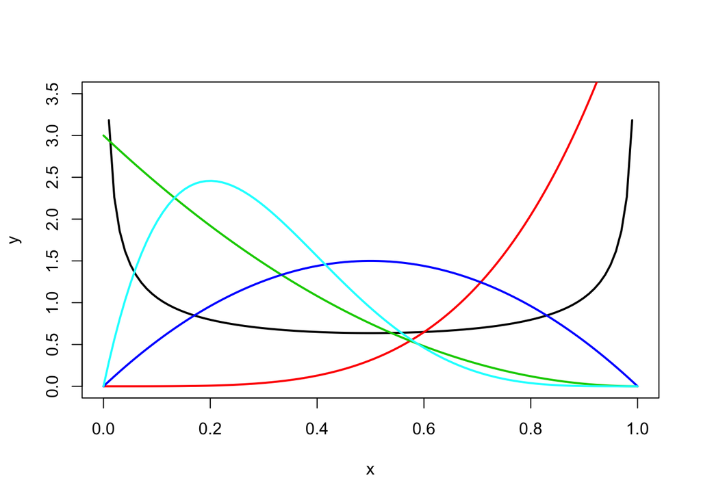

```r
#quick look at the various shapes of the beta distribution as we change the shape params:
AlphaBeta = cbind(alpha=c(0.5,5,1,2,2),beta=c(0.5,1,3,2,5))
M = nrow(AlphaBeta)
y= matrix(0,100,ncol=M)
x = seq(0,1,length=100)
for (i in 1:M) y[,i] = dbeta(x,AlphaBeta[i,1],AlphaBeta[i,2])
matplot(x,y,type="l", ylim = c(0,3.5), lty=1, lwd=2)
```